# Risk diagrams of COVID-19 in the UK and EU countries.

In this notebook, data from the European Comission's Joint Research Centre will be used to make risk diagrams of COVID-19 cumulative incidence and reproduction number.

It is impossible to know exactly how many people are infected in a pandemic, but the cumulative incidence $CI$ is an important factor, as it represents the new infections in the last $n$ days (in this case, 14). These are the people more prone to infecting other individuals, as they may not even know they have been infected yet. Crossing this value with the reproduction number $R$, which is roughly the ratio of new infections with respect to the original number of people with COVID-19, one obtains an estimate of the spread of the disease.

## 0. Packages and constants.

```python
import numpy as np
import pandas as pd

import matplotlib.pyplot as plt

import matplotlib.colors
from mpl_toolkits.axes_grid1 import make_axes_locatable

%matplotlib inline
```

```python
NAMED_COLORS = ['black', 'blue', 'red', 'yellow', 'lime', 'green', 'cyan', 'magenta', 'darkviolet']
MARKERS = ['o', 's', '^']
```

## 1. Data.

The data is taken from the European Comission's Joint Research Centre repository: https://github.com/ec-jrc/COVID-19. Only data from the UK and European countries will be used for this analysis.

```python
URL = 'https://raw.githubusercontent.com/ec-jrc/COVID-19/master/data-by-country/jrc-covid-19-all-days-by-country.csv'
df = pd.read_csv(URL)
df.head()
```

|  | Date | iso3 | CountryName | lat | lon | CumulativePositive | CumulativeDeceased | CumulativeRecovered | CurrentlyPositive | Hospitalized | IntensiveCare | EUcountry | EUCPMcountry | NUTS |
| --- | --- | --- | --- | --- | --- | --- | --- | --- | --- | --- | --- | --- | --- | --- |
| 0 | 2020-01-22 | GRC | Greece | 38.275283 | 23.810343 | 0 | 0.0 | 0.0 | 0.0 | NaN | NaN | True | True | EL |
| 1 | 2020-01-22 | ISL | Iceland | 64.963942 | -19.021169 | 0 | 0.0 | 0.0 | 0.0 | NaN | NaN | False | True | IS |
| 2 | 2020-01-22 | LIE | Liechtenstein | 47.164696 | 9.555000 | 0 | 0.0 | 0.0 | 0.0 | NaN | NaN | False | False | LI |
| 3 | 2020-01-22 | MCO | Monaco | 43.738348 | 7.424451 | 0 | 0.0 | 0.0 | 0.0 | NaN | NaN | False | False | MC |
| 4 | 2020-01-22 | MKD | North Macedonia | 41.611000 | 21.751417 | 0 | 0.0 | 0.0 | 0.0 | NaN | NaN | False | True | MK |

```python
mask = (df['CountryName'] == 'United Kingdom') | df['EUcountry']
df = df[mask]
```

```python
my_countries = np.sort(df['CountryName'].unique())
my_countries
```

```
array(['Austria', 'Belgium', 'Bulgaria', 'Croatia', 'Cyprus',
       'Czech Republic', 'Denmark', 'Estonia', 'Finland', 'France',
       'Germany', 'Greece', 'Hungary', 'Ireland', 'Italy', 'Latvia',
       'Lithuania', 'Luxembourg', 'Malta', 'Netherlands', 'Poland',
       'Portugal', 'Romania', 'Slovakia', 'Slovenia', 'Spain', 'Sweden',
       'United Kingdom'], dtype=object)
```

To be able to compare different countries, the $CI$ will be calculated as a proportion per 100,000 inhabitants. Therefore, the positive cases of infections will be divided by the total population of each country. This data is taken from the UN website: https://population.un.org/wpp/Download/Standard/Population/.

```python
POP_URL = 'https://population.un.org/wpp/Download/Files/1_Indicators%20(Standard)/EXCEL_FILES/1_Population/WPP2019_POP_F01_1_TOTAL_POPULATION_BOTH_SEXES.xlsx'
pop = pd.read_excel(POP_URL, skiprows=16)

pop = pop.iloc[24:]

pop = pop[['Region, subregion, country or area *', '2020']]
pop.columns = ['Country', '2020']
pop = pop.set_index('Country')

pop['2020'] = pd.to_numeric(pop['2020']) * 1000
pop.head()
```

| Country | 2020 |
| --- | --- |
| SUB-SAHARAN AFRICA | 1.094366e+09 |
| Eastern Africa | 4.454056e+08 |
| Burundi | 1.189078e+07 |
| Comoros | 8.695950e+05 |
| Djibouti | 9.880020e+05 |

```python
POPULATION = {}
found_countries = []
lost_countries = []

for country in my_countries:
    try:
        POPULATION[country] = pop.loc[country].values[0]
        found_countries.append(country)
    except:
        lost_countries.append(country)

print('These countries were not found:')
print(lost_countries)
```

```
These countries were not found:
['Czech Republic']
```

```python
lost_countries_names = ['Czechia', 'Republic of Moldova', 'Russian Federation']

pop = pop.reset_index()
for country, name in zip(lost_countries, lost_countries_names):
    mask = pop['Country'] == name
    pop.loc[mask, 'Country'] = country
    POPULATION[country] = pop.loc[mask, '2020'].values[0]

mask = pop['Country'].isin(my_countries)
pop = pop[mask]

pop = pop.sort_values('2020', ascending=False)
pop = pop.reset_index().drop(columns=['index'])
```

```python
pop.head()
```

|  | Country | 2020 |
| --- | --- | --- |
| 0 | Germany | 83783945.0 |
| 1 | United Kingdom | 67886004.0 |
| 2 | France | 65273512.0 |
| 3 | Italy | 60461828.0 |
| 4 | Spain | 46754783.0 |

```python
def preprocess(df):
    df = df.copy()

    # Select the countries defined in POPULATION.
    mask = df['CountryName'].isin(POPULATION.keys())
    df = df[mask]

    # Drop columns.
    drop_cols = ['iso3', 'lat', 'lon', 'EUcountry', 'EUCPMcountry', 'NUTS']
    df = df.drop(columns=drop_cols)

    # Rename columns and select the interesting ones.
    df.columns = ['DATE', 'COUNTRY', 'CUM_POS', 'CUM_DEC', 'CUM_REC', 'POS', 'HOS', 'INT']
    df = df[['DATE', 'COUNTRY', 'CUM_POS']]

    # Determine index and sort (no need to parse datetime, the format yyyy-mm-dd is good enough to sort).
    df = df.set_index('DATE')
    df = df.sort_index()

    return df
```

```python
df.tail()
```

|  | Date | iso3 | CountryName | lat | lon | CumulativePositive | CumulativeDeceased | CumulativeRecovered | CurrentlyPositive | Hospitalized | IntensiveCare | EUcountry | EUCPMcountry | NUTS |
| --- | --- | --- | --- | --- | --- | --- | --- | --- | --- | --- | --- | --- | --- | --- |
| 14212 | 2021-01-23 | EST | Estonia | 58.596209 | 25.023778 | 40184 | 368.0 | NaN | 39816.0 | NaN | NaN | True | True | EE |
| 14213 | 2021-01-23 | FIN | Finland | 64.952416 | 26.068944 | 42334 | NaN | NaN | 42334.0 | NaN | NaN | True | True | FI |
| 14214 | 2021-01-23 | DEU | Germany | 51.165706 | 10.452764 | 2122679 | 51521.0 | 1795400.0 | 275758.0 | NaN | NaN | True | True | DE |
| 14215 | 2021-01-23 | HUN | Hungary | 47.164638 | 19.508944 | 358317 | 11904.0 | 239880.0 | 106533.0 | 3854.0 | 259.0 | True | True | HU |
| 14216 | 2021-01-23 | LVA | Latvia | 56.875584 | 24.607722 | 60496 | 1097.0 | NaN | 59399.0 | NaN | NaN | True | True | LV |

```python
df = preprocess(df)
df.tail()
```

| DATE | COUNTRY | CUM_POS |
| --- | --- | --- |
| 2021-01-23 | Estonia | 40184 |
| 2021-01-23 | Finland | 42334 |
| 2021-01-23 | Germany | 2122679 |
| 2021-01-23 | Hungary | 358317 |
| 2021-01-23 | Latvia | 60496 |

```python
def process(df, countries):

    output = pd.DataFrame([])
    indexs = list(set(df.index.to_list()))

    for country in countries:

        # Subset of df.
        my_df = df.copy()
        mask = my_df['COUNTRY'] == country
        my_df = my_df[mask]

        # Ensure it is sorted.
        my_df = my_df.sort_index()

        # Compute Cumulative Incidence 14.
        my_df['POS'] = my_df['CUM_POS'] - my_df['CUM_POS'].shift(1)
        my_df['CUM14'] = my_df['POS'].rolling(window=14).sum()
        my_df['CI14'] = my_df['CUM14'] / POPULATION[country] * 1e5

        # Compute R7.
        pos = my_df['POS']
        my_df['R'] = (pos.shift(-1) + pos + pos.shift(1))/(pos.shift(4) + pos.shift(5) + pos.shift(6))

        r = my_df['R']
        my_df['R7'] = (r.shift(-3) + r.shift(-2) + r.shift(-1) + r + r.shift(1) + r.shift(2) + r.shift(3))/7

        # Drop rows with NAN values (due to computation with shifts).
        my_df = my_df.dropna()

        # Save result to new df.
        output = pd.concat([output, my_df])

        # Intersect dates.
        indexs = list(set(indexs) & set(my_df.index.to_list()))

    # Save only dates that all countries have and sort.
    output = output.loc[indexs]
    output = output.sort_index()

    return output
```

The risk ranges and the special calculation of $R$ are taken from the BIOCOMSC research group from the UPC: https://biocomsc.upc.edu/en.

```python
# Risk ranges:
# 0 to 30 --> VERY LOW
# 30 to 70 --> LOW
# 70 to 100 --> MEDIUM
# 100 to 200 --> HIGH
# 200 to infinity --> VERY HIGH

ranges = np.array([0, 30, 70, 100, 200])

nodes = (ranges[1:] - ranges[:-1])/2 + ranges[:-1]
nodes[0] = ranges[0]
nodes[-1] = ranges[-1]

# Normalize nodes.
nodes = nodes/max(nodes)
```

```python
colors = ['lime', 'yellow', 'orange', 'red', 'red']
cmap = matplotlib.colors.LinearSegmentedColormap.from_list('mycmap', list(zip(nodes, colors)))
```

```python
def add_text(ax, xmin, xmax, ymin, ymax, x, y, text):
    if (xmin < x) & (x < xmax) & (ymin < y) & (y < ymax):
        ax.text(x, y, text)
```

```python
def risk_plot(df, countries, ndays):

    df = df.copy()
    df = process(df, countries)

    # To determine the range needed to make the meshgrid...
    ci14 = []
    r7 = []

    for country in countries:
        my_df = df.copy()
        mask = my_df['COUNTRY'] == country
        my_df = my_df[mask].tail(ndays)

        ci14 = np.concatenate([ci14, my_df['CI14'].to_list()])
        r7 = np.concatenate([r7, my_df['R7'].to_list()])

    xmin = min(ci14)
    xmax = max(ci14)
    ymin = min(r7)
    ymax = max(r7)

    dx = (xmax - xmin)/4
    dy = (ymax - ymin)/4

    xmin = max(xmin - 3*dx, 0)
    xmax = xmax + dx
    ymin = max(ymin - 3*dy, 0)
    ymax = ymax + dy

    # Meshgrid.
    n = 100
    x = np.linspace(xmin, xmax, n)
    y = np.linspace(ymin, ymax, n)

    X, Y = np.meshgrid(x, y)

    # Risk = CI * R.
    Z = X*Y

    # For the title.
    date = my_df.index.values

    # PLOT.
    plt.figure(figsize=(10, 10))
    ax = plt.gca()
    ax.set_title('Risk diagram from {} to {}'.format(min(date), max(date)))
    ax.set_xlabel('CI$_{14}$ (cumulative incidence)')
    ax.set_ylabel('R$_7$ (reproduction number)')
    ax.set_xlim(xmin, xmax)
    ax.set_ylim(ymin, ymax)

    # Risk.
    im = ax.imshow(Z, origin='lower', interpolation='sinc', cmap=cmap,
                   extent=[xmin, xmax, ymin, ymax], aspect='auto', alpha=0.5)
    im.set_clim(0, 200)

    # Risk ranges.
    ax.contour(X, Y, Z, levels=[30, 200], colors='black', linewidths=1, linestyles='dashed')

    add_text(ax, xmin, xmax, ymin, ymax, 50, 0.1, 'Low risk')
    add_text(ax, xmin, xmax, ymin, ymax, 450, 0.2, 'Medium risk')
    add_text(ax, xmin, xmax, ymin, ymax, 1000, 0.3, 'High risk')

    # R = 1.
    ax.plot([0, xmax], [1, 1], color='black', linewidth=1, linestyle='dashed')

    # Scatter.
    for i, country in enumerate(countries):
        my_df = df.copy()
        mask = my_df['COUNTRY'] == country
        my_df = my_df[mask].tail(ndays)

        color = NAMED_COLORS[i%len(NAMED_COLORS)]
        marker = MARKERS[(i//len(NAMED_COLORS))%len(MARKERS)]

        ax.plot(my_df['CI14'], my_df['R7'], color=color)
        ax.scatter(my_df['CI14'], my_df['R7'], color=color, marker=marker, label=country)

        last = my_df.tail(1)

        ax.scatter(last['CI14'], last['R7'], facecolor='white', edgecolor='black', marker=marker, s=70)

    ax.legend()
    plt.show()
```

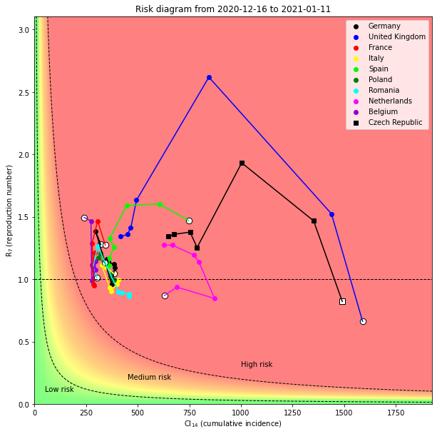

```python
top10_countries = pop.head(10)['Country'].to_list()
risk_plot(df, top10_countries, 7)
```

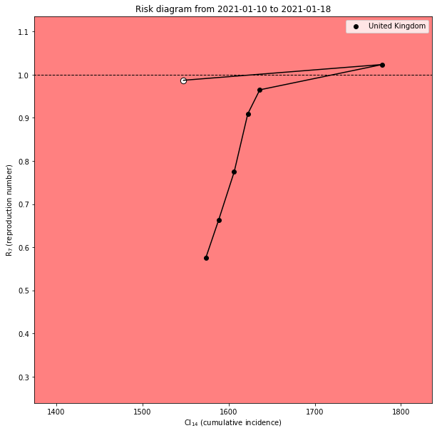

```python
my_choice = ['United Kingdom']
risk_plot(df, my_choice, 7)
```

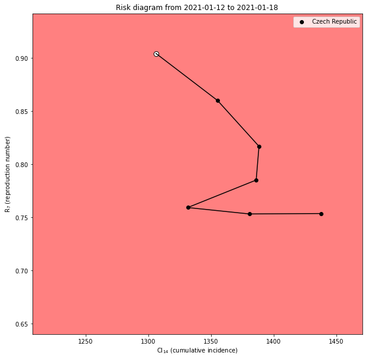

```python
my_choice = ['Czech Republic']
risk_plot(df, my_choice, 7)
```

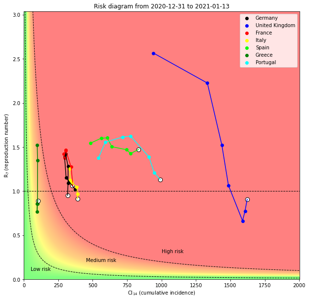

```python
my_choice = ['Germany', 'United Kingdom', 'France', 'Italy', 'Spain', 'Greece', 'Portugal']
risk_plot(df, my_choice, 7)
```

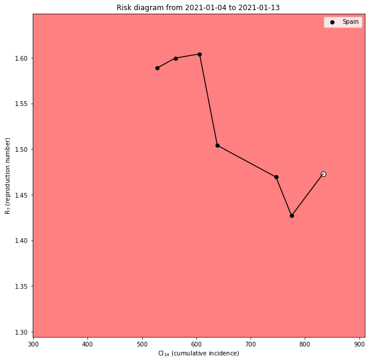

```python
my_choice = ['Spain']
risk_plot(df, my_choice, 7)
```

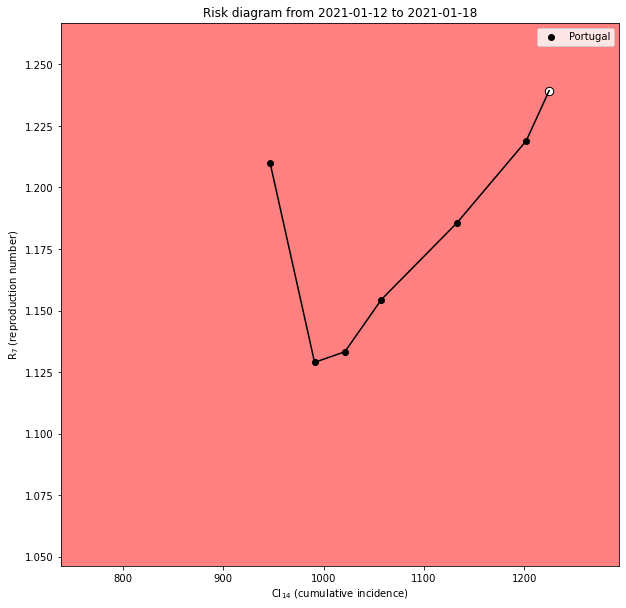

```python
my_choice = ['Portugal']
risk_plot(df, my_choice, 7)
```

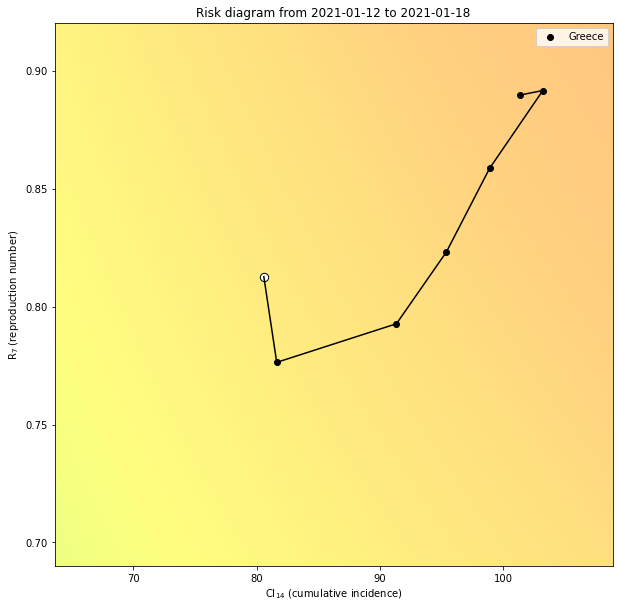

```python
my_choice = ['Greece']
risk_plot(df, my_choice, 7)
```